# LiveSessionUnit3

Joshua Yi

September 12, 2018

# Q1: GitHub Cloning

```r
#$ cd 'E:\Documents\School\MSDS 6306\Unit 3'
#$ git clone https://github.com/awesomedata/awesome-public-datasets.git
```

# Q2a-b: Data Summary

- In R, please read in titanic.csv via either read.table() or read.csv(), assigning it to df. This dataset follows the passengers aboard the Titanic, including their fees paid, rooms rented, and survivorship status.
- Output the respective count of females and males aboard the Titanic. Plot the frequency of females and males. Be sure to give an accurate title and label the axes.

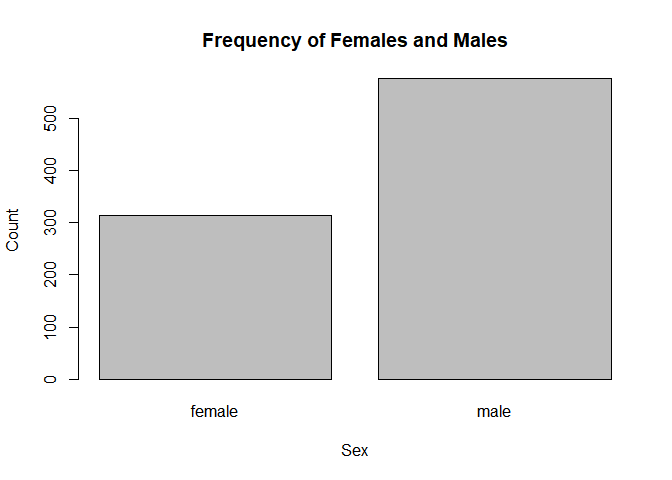

```r
# Calling in the data set from excel
df <-read.csv(file="E:\\Documents\\School\\MSDS 6306\\Unit 3\\awesome-public-datasets\\Datasets\\titanic.csv",header =TRUE, sep=",")
# plotting
plot(df$Sex, main="Frequency of Females and Males", xlab = "Sex", ylab ="Count")
```

# Q2c: Data Summary

- Please use one apply function (to review: swirl() modules 11, 12) to output the means of Age, Fare, and Survival. Make sure the output is a real number for all three means.

```r
# creating mean function
titanic.means <- function(my_vector){
  # Sapply function to use vector for indexing on the dataframe
  sapply(df[my_vector],mean,na.rm = TRUE)
}
# output
titanic.means(c(2,6,10))
```

```
##   Survived        Age       Fare
##  0.3838384 29.6991176 32.2042080
```

# Q3A: Function Building

- Create objects for the median Age, the minimum and maximum Duration of sleep, and the mean and standard deviation of the Rosenberg Self Esteem scale (RSES). You may need to specify a few options like in Problem 2 and live session.

```r
# reading from excel file
RSES <-read.csv(file="E:\\Documents\\School\\MSDS 6306\\Unit 3\\sleep_data_01.csv",header =TRUE, sep=",")
# Creating function
RSES.func <- function(x){
  # sapply function to go through each column index and apply functions
  age.mean <- mean(RSES$Age,na.rm = TRUE)
  # min duration object
  dur.min <- min(RSES$Duration, na.rm = TRUE)
  # max duration object
  dur.max <- max(RSES$Duration, na.rm =  TRUE)
  # mean RSES object
  RS.mean <- mean(RSES$RSES,na.rm = TRUE)
  # SD RSES object
  RS.sd <- sd(RSES$RSES,na.rm = TRUE)
  return(
    data.frame(
      age.mean,
      dur.min,
      dur.max,
      RS.mean,
      RS.sd
    )
  )
}
# mean age object
RSES.func(x)
```

```
##   age.mean dur.min dur.max  RS.mean    RS.sd
## 1       14       4      11 18.11494 6.176522
```

# Q3b: Function Building

- Create a data.frame object called report: it should consist of the median age, the RSES mean and standard deviation respectively divided by five (since there are five questions and these scores are summed), and the range of Duration (the statistical definition of range; it should be a single number.)

```r
# Creating function
report <- function(x){
  # age divide by 5
  age.mean2 <- RSES.func()$age.mean/5
  # RS mean divide by 5
  RS.mean2 <- RSES.func()$RS.mean/5
  # RS SD divide by 5
  RS.sd2 <- RSES.func()$RS.sd/5
  # range
  Rng <- (RSES.func()$dur.max-RSES.func()$dur.min)
  return(
    data.frame(
      age.mean2,
      RS.mean2,
      RS.sd2,
      Rng
    )
  )
}
# output
report(x)
```

```
##   age.mean2 RS.mean2   RS.sd2 Rng
## 1       2.8 3.622989 1.235304   7
```

# Q3c: Function Building

- Change the column names of this data.frame to MedianAge, SelfEsteem, SE_SD, and DurationRange.

```r
# create function
col.name <- function(x){
  # assign object for column name change
  colnames(x) <- c("MedianAge","SelfEsteem","SE_SD","DurationRange")
  return(x)
}
# create object
report <- col.name(report(x))
# call object
report
```

```
##   MedianAge SelfEsteem    SE_SD DurationRange
## 1       2.8   3.622989 1.235304             7
```

# Q3d: Function Building

- Round the report to at most 2 digits: leave this as the closing line to the function.

```r
# create function to round
r.report <- function(x){
  # rounding by 2
  round(x,digits = 2)
}
```

# Q3e: Function Building

- Finally, run the function on your sleep data to show the output.

```r
# call round function
r.report(report)
```

```
##   MedianAge SelfEsteem SE_SD DurationRange
## 1       2.8       3.62  1.24             7
```

# Q4a: FiveThrityEight Data

- Install the fivethirtyeight package.

```r
#install.packages("fivethirtyeight")
```

# Q4b: FiveThrityEight Data

- In the listing of Data sets in package ‘fivethirtyeight,’ assign the 22nd data set to an object ‘df.’

```r
f <- data(package = "fivethirtyeight")
df <- f$results[22,"Item"]
df
```

```
##                   Item
## "college_recent_grads"
```

# Q4c: FiveThrityEight Data

- Use a more detailed list of the data sets to write out the URL in a comment to the related news story.

```r
library(fivethirtyeight)
vignette("fivethirtyeight", package = "fivethirtyeight")
```

```
## starting httpd help server ... done
```

```r
# Commenting in the URL link
# http://fivethirtyeight.com/features/the-economic-guide-to-picking-a-college-major/
```

# Q4d: FiveThrityEight Data

- Using R command(s), give the dimensions and column names of this data frame.

```r
r.df <- fivethirtyeight::college_recent_grads
# column names
names(r.df)
```

```
##  [1] "rank"                        "major_code"
##  [3] "major"                       "major_category"
##  [5] "total"                       "sample_size"
##  [7] "men"                         "women"
##  [9] "sharewomen"                  "employed"
## [11] "employed_fulltime"           "employed_parttime"
## [13] "employed_fulltime_yearround" "unemployed"
## [15] "unemployment_rate"           "p25th"
## [17] "median"                      "p75th"
## [19] "college_jobs"                "non_college_jobs"
## [21] "low_wage_jobs"
```

```r
# get output number of Rows, Number of Columns
dim(r.df)
```

```
## [1] 173  21
```

# Q5a: Data Summary

- Write an R command that gives you the column names of the data frame. Right after that, write one that counts the number of columns but not rows. Hint: The number should match one of your numbers in Question 1d for dimensions.

```r
# column names
names(r.df)
```

```
##  [1] "rank"                        "major_code"
##  [3] "major"                       "major_category"
##  [5] "total"                       "sample_size"
##  [7] "men"                         "women"
##  [9] "sharewomen"                  "employed"
## [11] "employed_fulltime"           "employed_parttime"
## [13] "employed_fulltime_yearround" "unemployed"
## [15] "unemployment_rate"           "p25th"
## [17] "median"                      "p75th"
## [19] "college_jobs"                "non_college_jobs"
## [21] "low_wage_jobs"
```

```r
# number of columns
ncol(r.df)
```

```
## [1] 21
```

# Q5b: Data Summary

- Generate a count of each unique major_category in the data frame. I recommend using libraries to help. To be clear, this should look like a matrix or data frame containing the major_category and the frequency it occurs in the dataset. Assign it to major_count.

```r
  # Using dplyr to list unique major and get count of each major, placed into variable
  major_count <- dplyr::count(r.df,r.df$major_category)
  # renaming columns
  colnames(major_count) = c("Major","Count")
  # output variable
  major_count
```

```
## # A tibble: 16 x 2
##    Major                               Count
##    <chr>                               <int>
##  1 Agriculture & Natural Resources        10
##  2 Arts                                    8
##  3 Biology & Life Science                 14
##  4 Business                               13
##  5 Communications & Journalism             4
##  6 Computers & Mathematics                11
##  7 Education                              16
##  8 Engineering                            29
##  9 Health                                 12
## 10 Humanities & Liberal Arts              15
## 11 Industrial Arts & Consumer Services     7
## 12 Interdisciplinary                       1
## 13 Law & Public Policy                     5
## 14 Physical Sciences                      10
## 15 Psychology & Social Work                9
## 16 Social Science                          9
```

# Q5c: Data Summary

- To make things easier to read, put par(las=2) before your plot to make the text perpendicular to the axis. Make a barplot of major_count. Make sure to label the title with something informative (check the vignette if you need), label the x and y axis, and make it any color other than grey. Assign the major_category labels to their respective bar. Flip the barplot horizontally so that bars extend to the right, not upward. All of these options can be done in a single pass of barplot(). Note: It’s okay if it’s wider than the preview pane.

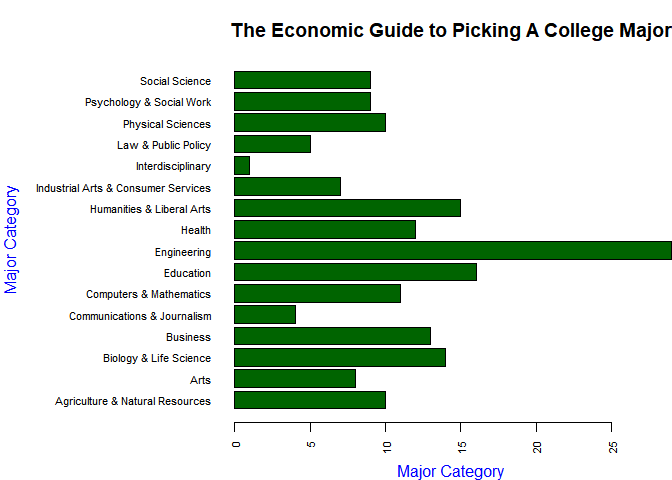

```r
  par(las=2)
  # changing the margins
  par(mar=c(3,12,3,0))
  # changing the axis font size
  par(cex.axis=.7)
  # building bar plot
  barplot(major_count$Count,horiz = TRUE,names.arg = major_count$Major ,col="dark green",
          # main title
          main = "The Economic Guide to Picking A College Major"
          ,cex.lab = .5)
  # changing the margin and creating the ylab title
  title(ylab = "Major Category", cex.lab = 1,
      line = 11,col.lab = 20)
  # changing the margin and creating the xlab title
    title(xlab = "Major Category", cex.lab = 1,
      line = 2,col.lab = 20)
```

# Q5d: Data Summary

- Write the fivethirtyeight data to a csv file. Make sure that it does not have row labels.

```r
require(RCurl)
# grabbing raw data from fivethirtyeight
Git.raw <- read.csv(text=getURL("https://raw.githubusercontent.com/rudeboybert/fivethirtyeight/master/data-raw/college-majors/recent-grads.csv"), header=T)
# writing the raw github data to a new csv file called "recentgrad"
write.csv(Git.raw, file = 'E:\\Documents\\School\\MSDS 6306\\Unit 3\\recentgrad.csv', row.names = FALSE)
```

# Q6a-d: codebook

- Start a new repository on GitHub for your SMU MSDS homework. On your local device, make sure there is a directory for Homework at the minimum; you are welcome to add whatever you would like to this repo in addition to your requirements here.
- Create a README.md file which explains the purpose of the repository, the topics included, the sources for the material you post, and contact information in case of questions. Remember, the one in the root directory should be general. You are welcome to make short READMEs for each assignment individually in other folders.
- In one (or more) of the nested directories, post your RMarkdown script, HTML file, and data from ‘fivethirtyeight.’ Make sure that in your README or elsewhere that you credit fivethirtyeight in some way.
- In your RMarkdown script, please provide the link to this GitHub so the grader can see it.

```r
# Github link: https://github.com/joshyi67/SMU-MSDS-Homework
```